# GP_6306_CaseStudy2

#### 4c. Give the frequencies (in table format or similar) for Gender, Work Status, and Occupation. They can be separate tables, if that’s your choice.

```r
# frequency helper function - column for frequency count and new column name for returned df
freq <- function(column, colName) {
  df <- as.data.frame(table(column))
  df <- df[df$column != "", ]
  df <- df[df$column != "0", ]
  names(df) <- c(colName, "Count")
  row.names(df) <- NULL
  df
}
```

##### Gender

```r
gender <- freq(column = df.procrastination$Gender, colName = "Gender")
kable(gender)
```

| Gender | Count |
| --- | --- |
| Female | 2196 |
| Male | 1645 |

##### Work Status

```r
workStatus <- freq(column = df.procrastination$WorkStatus, colName = "Work Status")
kable(workStatus)
```

| Work Status | Count |
| --- | --- |
| full-time | 2190 |
| part-time | 452 |
| retired | 162 |
| student | 780 |
| unemployed | 241 |

##### Occupation

```r
occupation <- freq(column = df.procrastination$Occupation, colName = "Occupation")
kable(occupation)
```

| Occupation | Count |
| --- | --- |
| Accountant | 2 |
| acupuncturist | 1 |
| admin assist | 2 |
| anthropologist | 1 |
| Assistant | 1 |
| bookseller | 1 |
| Communications | 2 |
| consultant | 12 |
| designer | 2 |
| Diplomat | 2 |
| Epidemiologist | 2 |
| houswife | 16 |
| innkeeper | 1 |
| Military | 1 |
| Research/Teaching Assistant | 1 |
| school | 0 |
| specialist | 1 |
| veterinarian | 2 |
| abc | 1 |
| Academic | 1 |
| Academic Assistant | 2 |
| academic/career coach & admin assistant | 1 |
| account planner | 1 |
| Account Service Rep | 1 |
| Accounting | 2 |
| Accounting Assistant | 1 |
| Accounts Payable | 1 |
| acounting analyst | 1 |
| Activities Leader | 1 |
| Actress | 1 |

[output cut: 363 more lines]

#### 4d. Give the counts (again, pretty table) of how many participants per country in descending order.

```r
participants <- freq(column = df.procrastination$Country, colName = "Country")
participants <- arrange(participants, desc(participants$Count))
kable(participants)
```

| Country | Count |
| --- | --- |
| United States | 2790 |
| Canada | 244 |
| United Kingdom | 177 |
| Australia | 99 |
| India | 78 |
| Italy | 62 |
| Germany | 36 |
| Brazil | 20 |
| Ireland | 19 |
| Netherlands | 18 |
| Sweden | 15 |
| Norway | 14 |
| France | 13 |
| Japan | 13 |
| Spain | 13 |
| China | 12 |
| Finland | 12 |
| Mexico | 12 |
| New Zealand | 12 |
| South Africa | 12 |
| Switzerland | 12 |
| Philippines | 11 |
| Greece | 10 |
| Belgium | 9 |
| Denmark | 9 |
| Turkey | 9 |
| Hong Kong | 7 |
| Portugal | 7 |
| Slovenia | 6 |
| Poland | 5 |

[output cut: 159 more lines]

#### 4e. There are two variables in the set: whether the person considers themselves a procrastinator (yes/no) and whether others consider them a procrastinator (yes/no). How many people matched their perceptions to others’ (so, yes/yes and no/no)? To clarify: how many people said they felt they were procrastinators and also said others thought they were procrastinators? Likewise, how many said they were not procrastinators and others also did not think they were procrastinators?

```r
  df.agree <- df.procrastination
  totals = function(x, y){
    value = "Disagree"
    if(x == "yes" && y == "yes") {
      value = "Both agree Yes"
    } else if(x == "no" && y == "no") {
      value = "Both agree No"
    }
    value
  }
  agreements = mapply(totals, df.agree$SelfView, df.agree$ExtView)
  df.agree$Agree <- agreements

  agree <- freq(column = df.agree$Agree, colName = "In Agreement")
  agree <- agree[agree$`In Agreement` != "Disagree", ]
  kable(agree)
```

| In Agreement | Count |
| --- | --- |
| Both agree No | 461 |
| Both agree Yes | 2255 |

# 5. Deeper Analysis and Visualization

#### 5a. Note: You should make all of these appealing looking. Remember to include things like a clean, informative title, axis labels that are in plain English, and readable axis values that do not overlap

#### 5b. Create a barchart in ggplot or similar which displays the top 15 nations in average procrastination scores, using one measure of the following: DP, AIP, or GP. The bars should be in descending order, with the number 1 most procrastinating nation at the top and 15th most procrastinating at the bottom. Omit all other nations. Color the bars by HDI category (see 3B). Use any color palette of your choice other than the default.

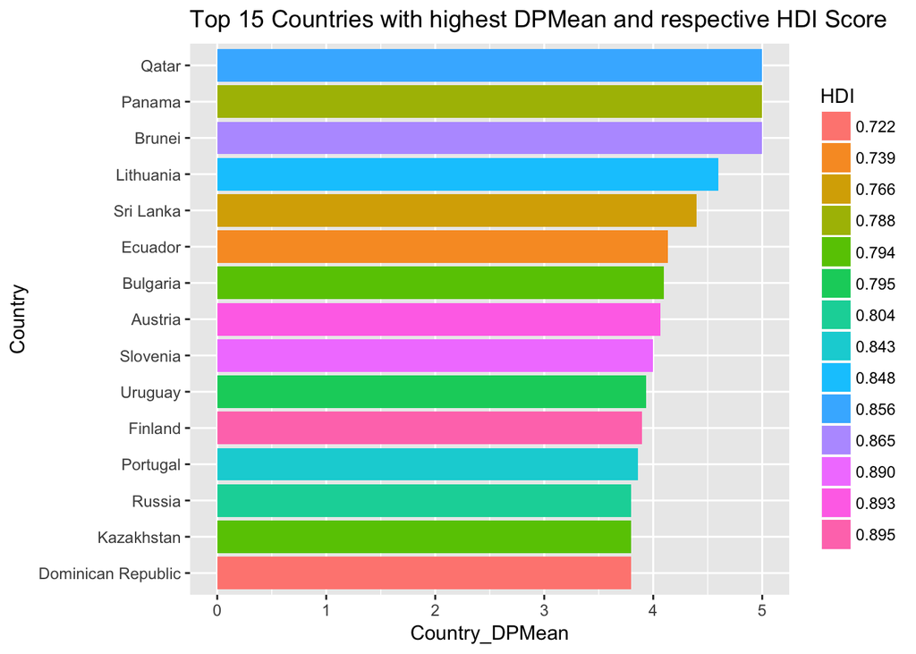

```r
options(digits = 4)
  top_15_DP_HDI <- df.procrastination %>% select(Country, DPMean, HDI) %>% arrange(Country) %>%
    group_by(Country, HDI) %>% summarise (Country_DPMean = mean(DPMean)) %>%
    arrange(desc(Country_DPMean)) %>% head(n=15)

  ggplot(top_15_DP_HDI, aes(x= reorder(Country, Country_DPMean), y=Country_DPMean)) + geom_bar(aes(fill=HDI), stat = "identity") +      ggtitle("Top 15 Countries with highest DPMean and respective HDI Score") + xlab("Country") + coord_flip() + scale_fill_hue(l=72)
```

#### 5c. Create another barchart identical in features to 5B, but use another one of the three variables: DP, AIP, or GP. How many nations show up both in 5B’s plot and 5C’s? Which, if any?

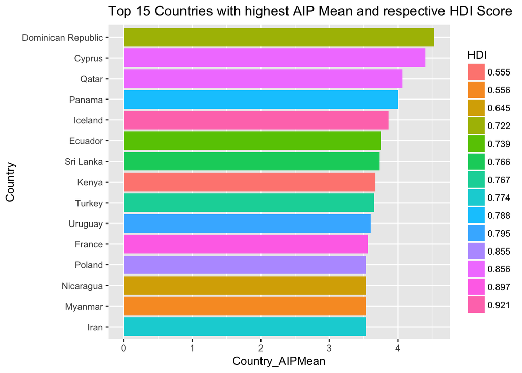

```r
options(digits = 4)
  top_15_AP_HDI <- df.procrastination %>% select(Country, AIPMean, HDI) %>% arrange(Country) %>%
    group_by(Country, HDI) %>% summarise (Country_AIPMean = mean(AIPMean)) %>%
    arrange(desc(Country_AIPMean)) %>% head(n=15)

ggplot(top_15_AP_HDI, aes(x= reorder(Country, Country_AIPMean), y=Country_AIPMean)) +        geom_bar(aes(fill=HDI), stat = "identity") +
ggtitle("Top 15 Countries with highest AIP Mean and respective HDI Score") +
xlab("Country") + coord_flip() + scale_fill_hue(l=72)
```

##### Countries Found in the Top 15 for both Decisional Procrastination and Procrastination Behavior

```r
df.union <- merge(x = top_15_AP_HDI, y = top_15_DP_HDI, by = "Country")
df.union$mean <- scaleMean(df = df.union, columns = c("Country_DPMean", "Country_AIPMean"))
df.union <- arrange(df.union, desc(df.union$mean))
df.union <- select(df.union, c("Country"))
kable(df.union, align = 'c', col.names = c("Top Procrastinators"))
```

| Top Procrastinators |
| --- |
| Qatar |
| Panama |
| Dominican Republic |
| Sri Lanka |
| Ecuador |
| Uruguay |

#### 5d. Is there a relationship between Age and Income? Create a scatterplot and make an assessment of whether there is a relationship. Color each point based on the Gender of the participant. You’re welcome to use lm() or similar functions to back up your claims.

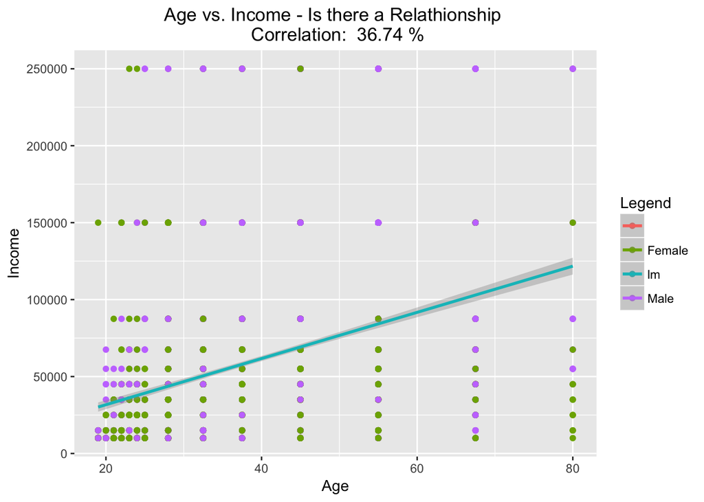

```r
  y <- round(cor(df.procrastination$Age, df.procrastination$Income, use = "complete.obs"),4)*100

  df.procrastination %>%
  ggplot(., aes(x=Age, y=Income)) +
  geom_point(aes(colour = factor(Gender)), na.rm = TRUE)  +
  geom_smooth(aes(color="lm"), method=lm, se=TRUE, na.rm = TRUE) +
  labs(color = "Legend") +
  ggtitle(paste("Age vs. Income - Is there a Relathionship \n Correlation: ", y,"%")) +
  theme(plot.title = element_text(hjust = 0.5))
```

##### Given the slope of the lm is up and to the right, this indicates a positive relationship between Age and Income.

#### 5e. What about Life Satisfaction and HDI? Create another scatterplot. Is there a discernible relationship there?

##### Scatterplot:

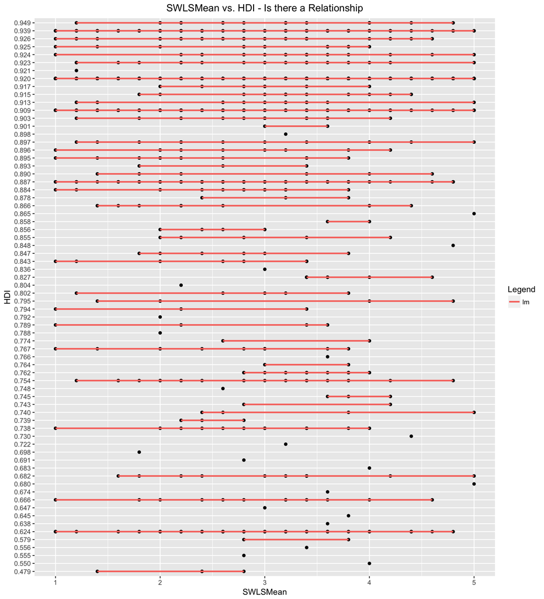

```r
  df.procrastination %>%
  ggplot(., aes(x=SWLSMean, y=HDI)) +
  geom_point(na.rm = TRUE)  +
  geom_smooth(aes(color="lm"), method=lm, se=FALSE, na.rm = TRUE) +
  labs(color = "Legend") +
  ggtitle("SWLSMean vs. HDI - Is there a Relationship") +
  theme(plot.title = element_text(hjust = 0.5))
```

##### It is difficult to discern a correlation between Life Satisfaction and the HDI based upon the above plot.

##### Barplot:

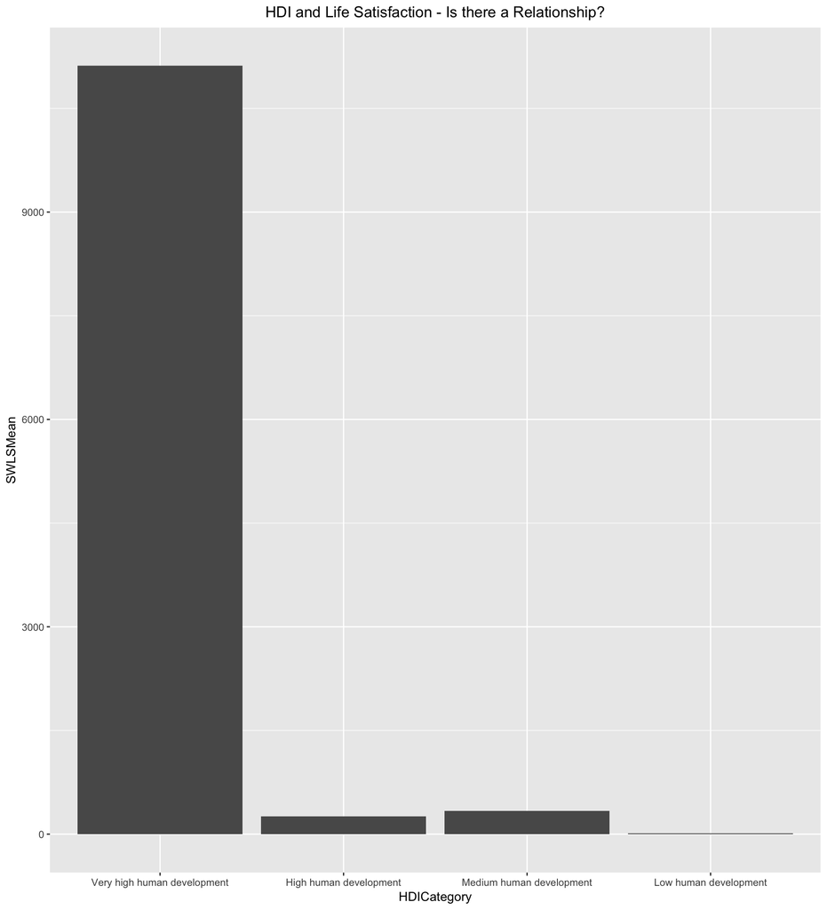

```r
  df.procrastination %>%
  ggplot(., aes(y = SWLSMean, x = HDICategory)) +
  geom_bar(stat = "identity", na.rm=TRUE) +
  labs(title = "HDI and Life Satisfaction - Is there a Relationship?") +
  theme(plot.title = element_text(hjust = 0.5))
```

#### 6a. The client would like the finalized HDI table (3A and 3B)

```r
write.csv(df.hdi, file = "../ClientCSV/HDIByCountry.csv", row.names = F)
```

#### 6b. The client would like the Tidied version of the original input to be output in the repository, including the merged HDI data (3C).

```r
write.csv(df.procrastination, file = "../ClientCSV/CompleteData.csv", row.names = F)
```

#### 6c. The client would like a dataset (or two) that shows the Top 15 nations (in 5B and 5C), as well as their HDI scores.

```r
write.csv(top_15_AP_HDI, file = "../ClientCSV/top_15_AIP.csv", row.names = F)
write.csv(top_15_DP_HDI, file = "../ClientCSV/top_15_DP.csv", row.names = F)
```

# The End Result? QATAR!!

```r
results <- merge(df.procrastination, df.union, by = "Country")
results.hdi <- results[results$HDICategory == 'Very high human development', ]
results.hdi <- select(results.hdi, c("Country"))
row.names(results.hdi) <- NULL
kable(results.hdi, align = 'c', col.names = c("Bronze's Gym's next location will be:"))
```

| Bronze’s Gym’s next location will be: |
| --- |
| Qatar |

#### According to our research, Qatar is the country best suited for our next Bronze’s Gym! Their high level of affluence in combination with their procrastination makes them the perfect location. Next, we’ll need to start a targeted add compain to get people into the gym. It may not be easy to get these procrastinators in there, but once we do the chances are very good that they will pay and go away!